# 2017 MLB Team Exploration: Mostly Injuries

Seth Goldman

October 28, 2017

Although the Washington Nationals have crashed out of the MLB playoffs for the [fourth time in four appearances](http://www.espn.com/blog/washington-nationals/post/_/id/3300/curses-nationals-playoff-dreams-are-foiled-again) since 2012, I’m not ready to put the 2017 season to bed. While practicing exploratory data analysis and plotting with [ggplot2](http://ggplot2.tidyverse.org/reference/), I downloaded a couple of datasets from the 2017 MLB Regular Season to play around with:

- Team Batting ([baseball reference](https://www.baseball-reference.com/leagues/MLB/2017.shtml))
- Team Pitching ([baseball reference](https://www.baseball-reference.com/leagues/MLB/2017.shtml))
- Team Disabled List data ([spotrac](http://www.spotrac.com/mlb/disabled-list/))

I have a pretty superficial understanding of modern sabermetrics (i.e., [FanGraphs](http://www.fangraphs.com) is often over my head, I couldn’t tell you how to calculate weighted on-base average, but I understand the concepts behind Run Expectancy, Win Probability Added, WAR, and a handful of popular measures). All this to say: this analysis won’t add much value to baseball research, but was fun to practice on.

With no particular goal in mind, I loaded in the 2017 Team Batting, and 2017 Team Pitching from bbref, and an American League/National League reference table, which I created myself.

Baseball Reference recently re-designed their table export functionality, where instead of downloading the table as a .csv, bbref displays a block of comma-separated text.

I loaded the data using readr’s `read_csv` function. The first three rows, below:

```r
team_batting <- read_csv("Tm,#Bat,BatAge,R/G,G,PA,AB,R,H,2B,3B,HR,RBI,SB,CS,BB,SO,BA,OBP,SLG,OPS,OPS+,TB,GDP,HBP,SH,SF,IBB,LOB
ARI,45,28.3,5.01,162,6224,5525,812,1405,314,39,220,776,103,30,578,1456,.254,.329,.445,.774,93,2457,106,54,39,27,44,1118
                         ATL,49,28.7,4.52,162,6216,5584,732,1467,289,26,165,706,77,31,474,1184,.263,.326,.412,.738,94,2303,137,66,59,32,57,1127
                         BAL,50,28.6,4.59,162,6140,5650,743,1469,269,12,232,713,32,13,392,1412,.260,.312,.435,.747,99,2458,138,50,10,37,12,1041")
```

Since the team summaries from bbref included *average* and *sum* rows, I had to remove these from my data.frames, and added the AL/NL key:

```r
team_batting <- team_batting %>%
  slice(1:30) %>%
  left_join(team_league, by = "Tm")

team_pitching <- team_pitching %>%
  slice(1:30) %>%
  left_join(team_league, by = "Tm")
```

### Player Appearances per Team

As I started to examine the tables, I had to return to bbref to look up the `#Bat` and `#P` variables, while represent the number of distinct *batters* and *pitchers* that appeared for each team.

To get a sense of the distribution of batters used by team, I created a box-and-whisker plot.

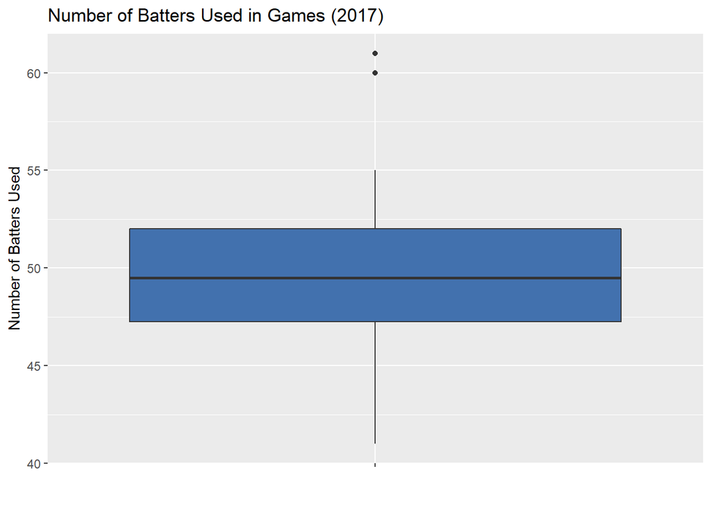

```r
ggplot(teams_playersused_wins, aes(x = "", y = n_batters)) +
  geom_boxplot(fill = "#4271AE") +
  ylab("Number of Batters Used") +
  xlab("") +
  ggtitle("Number of Batters Used in Games (2017)")
```

Since pitchers have to bat in the National League, I’d expect NL teams to have 4-5 more batters on average than the AL. After plotting the two leagues side-by-side, my hunch was disproved. I hadn’t considered interleague games, which reverse the effect.

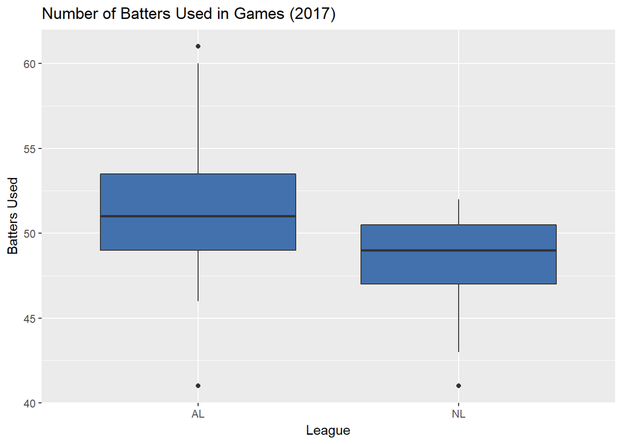

AL teams used three more batters than do NL team on average, but the outliers are interesting.

*Which teams used the **most** batters in each league?*

```
## # A tibble: 5 x 3
##      Tm n_batters    Lg
##   <chr>     <int> <chr>
## 1   SEA        61    AL
## 2   TOR        60    AL
## 3   LAA        55    AL
## 4   OAK        54    AL
## 5   TBR        53    AL
## # A tibble: 5 x 3
##      Tm n_batters    Lg
##   <chr>     <int> <chr>
## 1   LAD        52    NL
## 2   NYM        52    NL
## 3   SDP        52    NL
## 4   PHI        51    NL
## 5   MIL        50    NL
```

*Which teams used the **fewest** batters in each league?*

```
## # A tibble: 5 x 3
##      Tm n_batters    Lg
##   <chr>     <int> <chr>
## 1   CLE        41    AL
## 2   HOU        46    AL
## 3   BOS        49    AL
## 4   DET        49    AL
## 5   KCR        49    AL
## # A tibble: 6 x 3
##      Tm n_batters    Lg
##   <chr>     <int> <chr>
## 1   COL        41    NL
## 2   MIA        43    NL
## 3   ARI        45    NL
## 4   CHC        47    NL
## 5   CIN        47    NL
## 6   PIT        47    NL
```

Pretty interesting: Only one team among the top-5 of each league made the Postseason (LAD), compared to six of the ten teams among their league’s bottom-5 (CLE, HOU, BOS, COL, ARI, CHC).

#### Does this mean that using fewer batters tend to win more games?

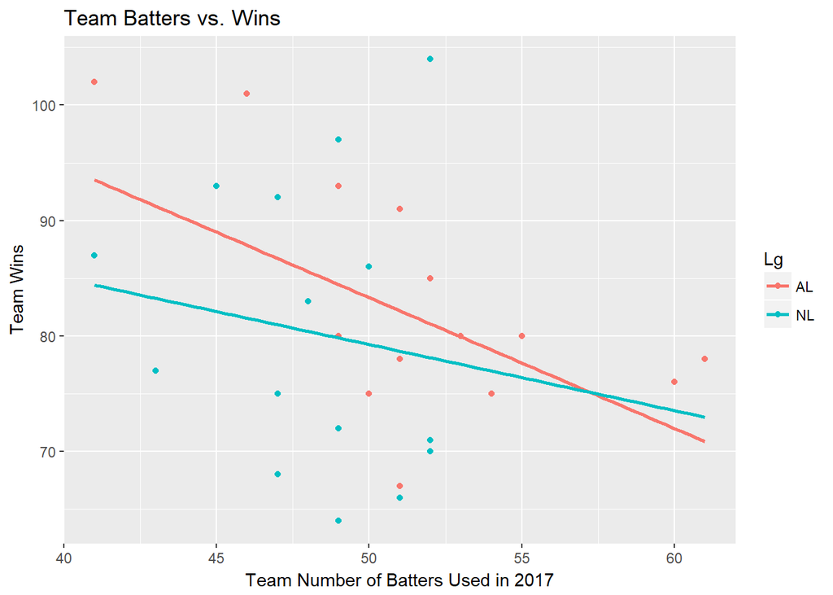

Overall, the correlation coefficient between Batters Used and Wins is -0.297201, a weak negative relationship. Among AL teams it’s -0.5112843, and for NL teams it’s -0.151149.

I anticipated the relationship to be stronger in the AL, with CLE, HOU, and BOS using the fewest batters in the AL, while combining for 296 wins. However, I wonder if these highly successful teams won more games with fewer players because they managed to avoid injuries, or simply better individual hitters among on their rosters.